# Homework_2

Francesco Mezzacasa

2025-05-30

# Homework 2

### 1)Si svolga l’analisi univariata di ciascuna variabile, proponendo visualizzazioni dei dati adeguate.

```r
df <- read.csv("fev.csv", stringsAsFactors = T)
str(df)
```

```
## 'data.frame':    654 obs. of  5 variables:
##  $ AGE   : int  9 8 7 9 9 8 6 6 8 9 ...
##  $ FEV   : num  1.71 1.72 1.72 1.56 1.9 ...
##  $ HEIGHT: num  57 67.5 54.5 53 57 61 58 56 58.5 60 ...
##  $ SEX   : Factor w/ 2 levels "Female","Male": 1 1 1 2 2 1 1 1 1 1 ...
##  $ SMOKE : Factor w/ 2 levels "Non-smoker","Smoker": 1 1 1 1 1 1 1 1 1 1 ...
```

Analisi della variabile AGE

```r
summary(df$AGE)
```

```
##    Min. 1st Qu.  Median    Mean 3rd Qu.    Max.
##   3.000   8.000  10.000   9.931  12.000  19.000
```

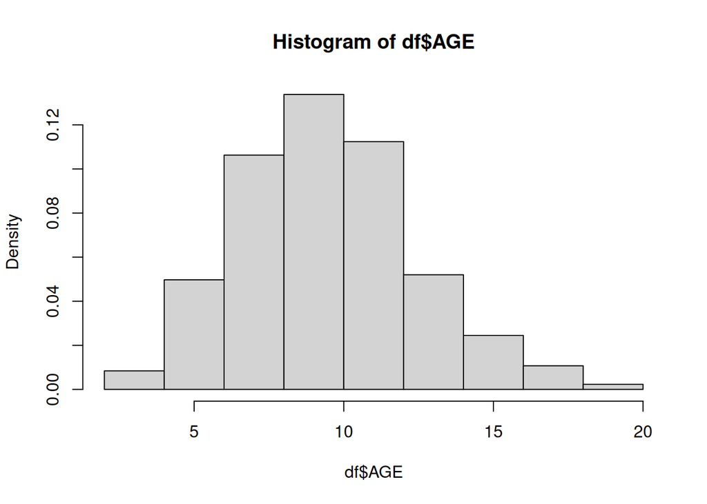

```r
hist(df$AGE, probability = T)
```

Analisi della variabile FEV

```r
summary(df$FEV)
```

```
##    Min. 1st Qu.  Median    Mean 3rd Qu.    Max.
##   0.791   1.981   2.547   2.637   3.119   5.793
```

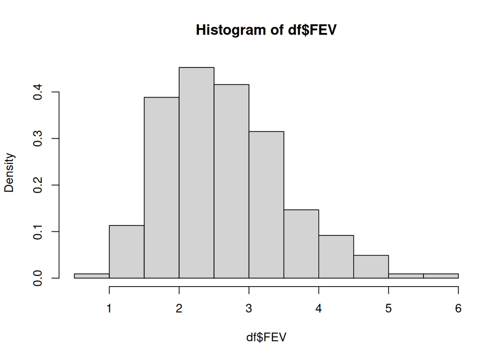

```r
hist(df$FEV, probability = T)
```

Analisi della variabile HEIGHT

```r
summary(df$HEIGHT)
```

```
##    Min. 1st Qu.  Median    Mean 3rd Qu.    Max.
##   46.00   57.00   61.50   61.14   65.50   74.00
```

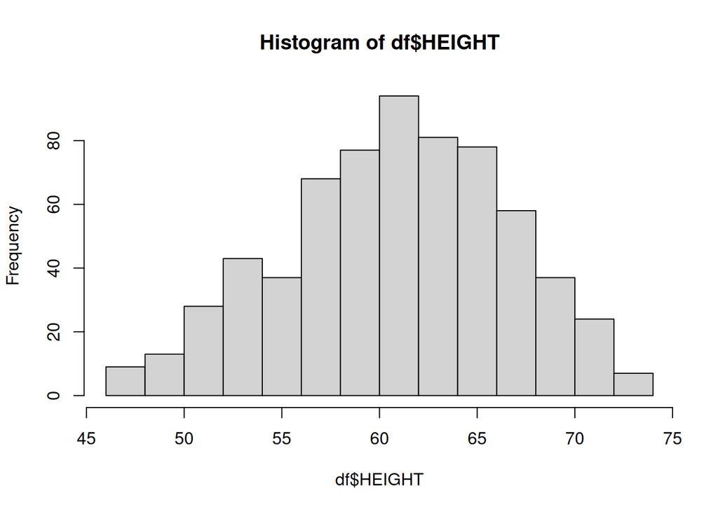

```r
hist(df$HEIGHT)
```

Analisi della variabile SEX

```r
prop.table(table(df$SEX))
```

```
##
##    Female      Male
## 0.4862385 0.5137615
```

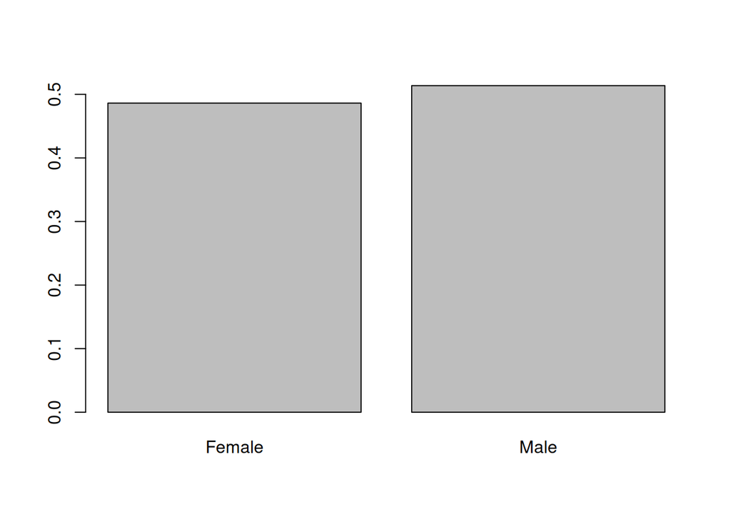

```r
barplot(prop.table(table(df$SEX)))
```

Analisi della variabile SMOKE

```r
prop.table(table(df$SMOKE))
```

```
##
## Non-smoker     Smoker
## 0.90061162 0.09938838
```

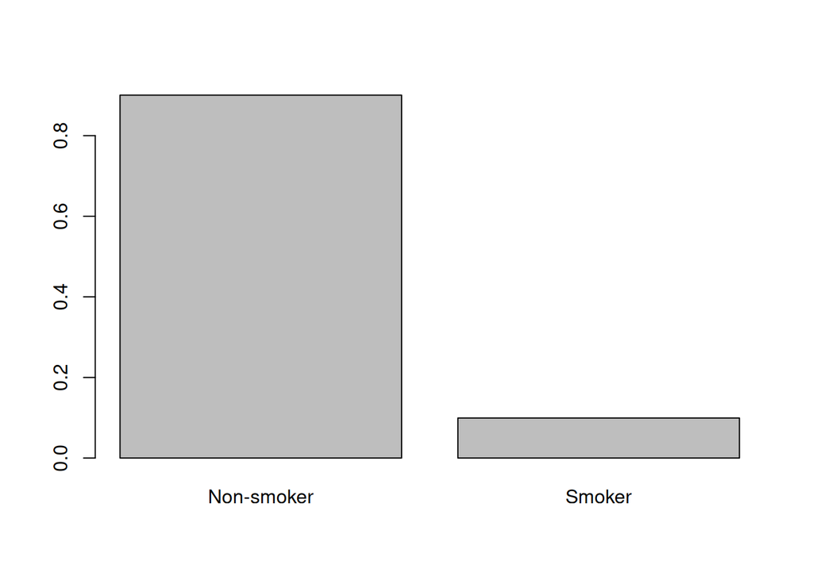

```r
barplot(prop.table(table(df$SMOKE)))
```

### 2) Si usi uno strumento grafico per evidenziare le eventuali differenze nella capacità polmonare per i maschi e le femmine.

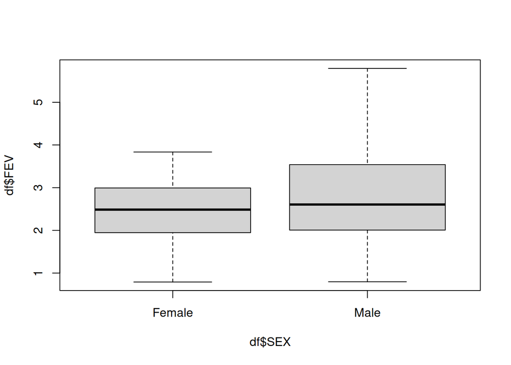

```r
boxplot(df$FEV ~ df$SEX)
```

### 3) Si conduca una analisi di regressione per prevedere la capacità polmonare utlizzando come predittore la statura e si fornisca la rappresentazione grafica e gli indici per valutare la qualità di tale rappresentazione. Cosa succede se la statura viene trasformata in centimetri?

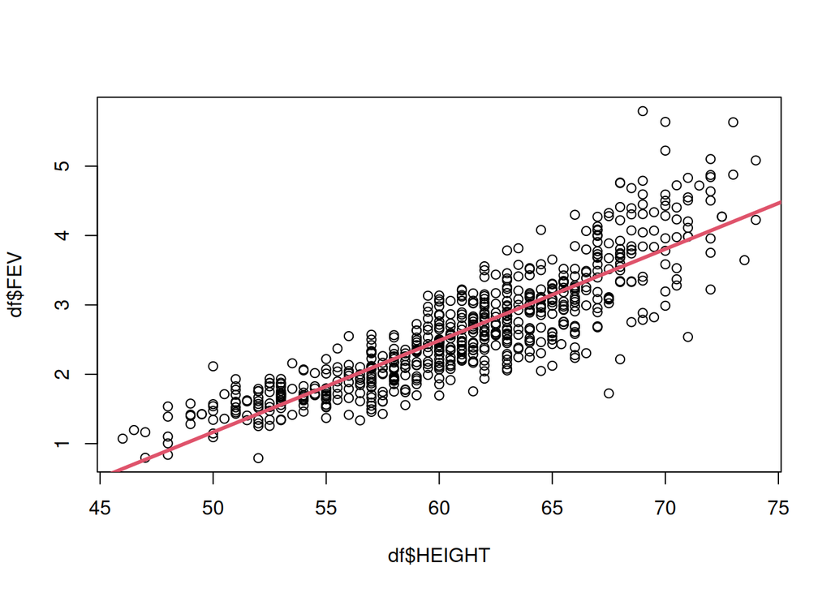

```r
plot(df$HEIGHT, df$FEV)

regresslin <- lm(df$FEV ~ df$HEIGHT)
coeff <- regresslin$coefficients
abline(coeff[1], coeff[2], col=2, lwd=3)
```

Uso il coefficiente R^2 per valutare la bontà

```r
n <- length(df$HEIGHT)
res <- regresslin$residuals
devtot <- var(df$FEV)*(n-1)
devres <- var(res)*(n-1)
R2 <- 1 - (devres/devtot)
print(R2)
```

```
## [1] 0.7536584
```

Vedo cosa succede se trasformo l’altezza in centimetri

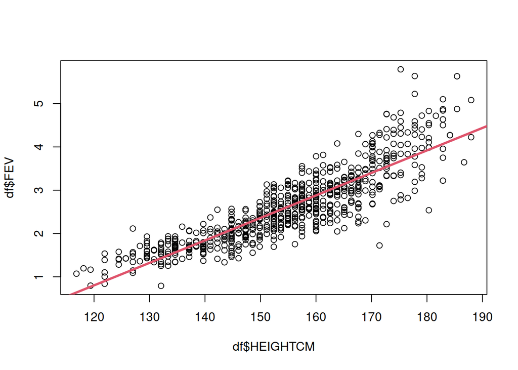

```r
df$HEIGHTCM = df$HEIGHT * 2.54
plot(df$HEIGHTCM, df$FEV)

regresslinCM <- lm(df$FEV ~ df$HEIGHTCM)
coeffCM <- regresslinCM$coefficients
abline(coeffCM[1], coeffCM[2], col=2, lwd=3)
```

Valuto la bontà della regressione con l’altezza in centimetri

```r
R2CM <- summary(regresslinCM)$r.squared
print(R2CM)
```

```
## [1] 0.7536584
```

Viene identico.

### 4) Si calcolino i residui della regressione di cui al punto 3 e si produca un grafico con sull’asse orizzontale il valore della variabile dipendente e su quello verticale i residui. Si aggiunga al grafico due linee orizzontali in corrispondenza di più o meno la radice quadrata della varianza dei residui.

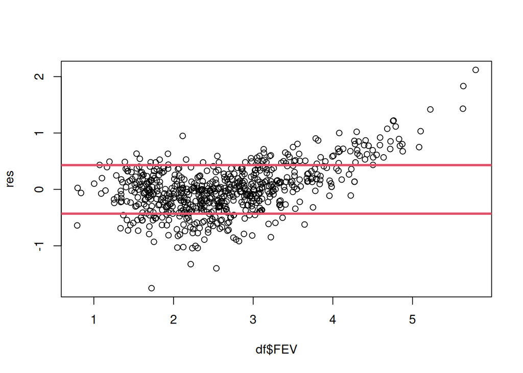

```r
plot(df$FEV, res)
abline(h = sqrt(var(res)), col = 2, lwd = 3)
abline(h = -sqrt(var(res)), col = 2, lwd = 3)
```

### 5) Si ipotizzi che la relazione fra le due variabili non sia lineare, ma lineare a tratti. Cioè si immagini che vi sia una relazione lineare per le stature fino a 63 pollici e un’altra per le stature oltre 63. Si svolga l’analisi e si rappresenti questa su un grafico.

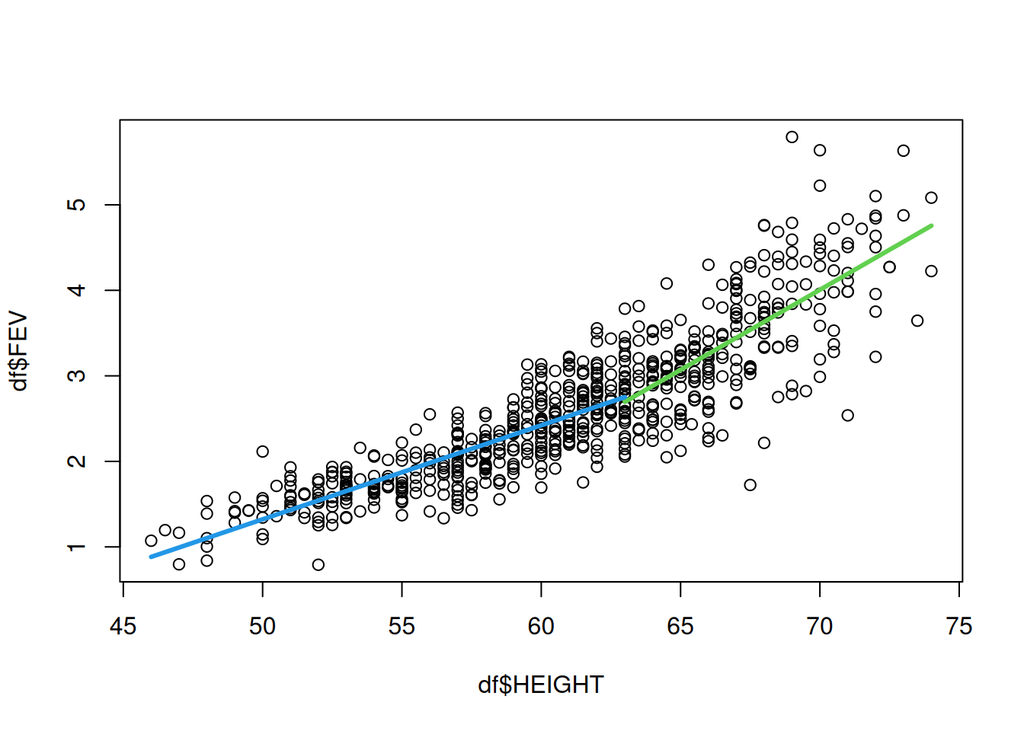

```r
bassi <- df[df$HEIGHT <= 63, ]
alti <- df[df$HEIGHT >= 63, ]

plot(df$HEIGHT, df$FEV)

modelloalti <- lm(alti$FEV ~ alti$HEIGHT)
modellobassi <- lm(bassi$FEV ~bassi$HEIGHT)
coeffalti <- modelloalti$coefficients
coeffbassi <- modellobassi$coefficients
x_alti <- seq(min(alti$HEIGHT), max(alti$HEIGHT))
lines(x_alti, (x_alti*coeffalti[2] + coeffalti[1]), col = 3, lwd = 3)
x_bassi <- seq(min(bassi$HEIGHT), max(bassi$HEIGHT))
lines(x_bassi, (x_bassi*coeffbassi[2] + coeffbassi[1]), col = 4, lwd = 3)
```

### 6) Si valuti la qualità della regressione a tratti con un opportuno misura in cui la qualità dipende dalla distanza del valore osservato da quello previsto al quadrato. Si confronti con quanto ottenuto al punto 3 e si commenti.

Calcolo il coefficiente R^2 con i residui calcolati dalla retta appropriata

```r
resalti <- modelloalti$residuals
devresalti <- var(resalti)*(length(alti$HEIGHT)-1)
resbassi <- modellobassi$residuals
devresbassi <- var(resbassi)*(length(bassi$HEIGHT)-1)

R2tratti <- 1 - ((devresbassi + devresalti)/devtot)
print(R2tratti)
```

```
## [1] 0.7604902
```

Viene un po’ meglio dell’altro

### 7) Si svolga una analisi come al punto 5 ma imponendo che fra la seconda retta di regressione (quella per i soggetti più alti) e la prima (per i soggetti bassi) non vi sia discontinuità. Ovvero la retta di regressione fino a 63 ha in quel punto lo stesso valore della retta che parte da 63 in poi. Anche in questo caso si misuri la qualità della analisi e si confronti.

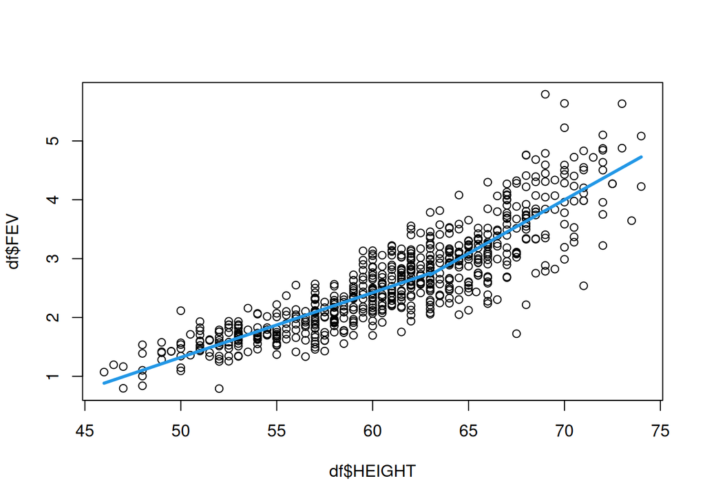

```r
altezza_extra <- ifelse(df$HEIGHT > 63, df$HEIGHT - 63, 0)
modellocontinuo <- lm(df$FEV ~ df$HEIGHT + altezza_extra)
coeffcontinuo <- modellocontinuo$coefficients

plot(df$HEIGHT, df$FEV)
lines(x_bassi, (x_bassi*coeffbassi[2] + coeffbassi[1]), col = 4, lwd = 3)
lines(x_alti, (coeffcontinuo[1] + x_alti*coeffcontinuo[2] + (x_alti - 63)*coeffcontinuo[3]), col = 4, lwd = 3)
```